# Lecture

## Vector autoregression (VAR) model

Previously we assumed unidirectional relationship between forecast variable and the predictor variables, but there are cases when the converse relationship exists, too.

We can model such situations in the vector autoregressive (VAR) framework. A VAR model is a generalisation of the univariate autoregressive model for forecasting a vector of time series, one equation per variable in the system.

Consider a 2-dimensional VAR(1) model: $$ \begin{aligned} y_{1,t} & = c_1 + \alpha_{1,1,1} y_{1,t-1} + \alpha_{1,2,1} y_{2,t-1} + \varepsilon_{1, t} \\ y_{2,t} & = c_2 + \alpha_{2,1,1} y_{1,t-1} + \alpha_{2,2,1} y_{2,t-1} + \varepsilon_{2, t} \end{aligned} $$

```python
from darts.utils.statistics import plot_ccf, check_seasonality
```

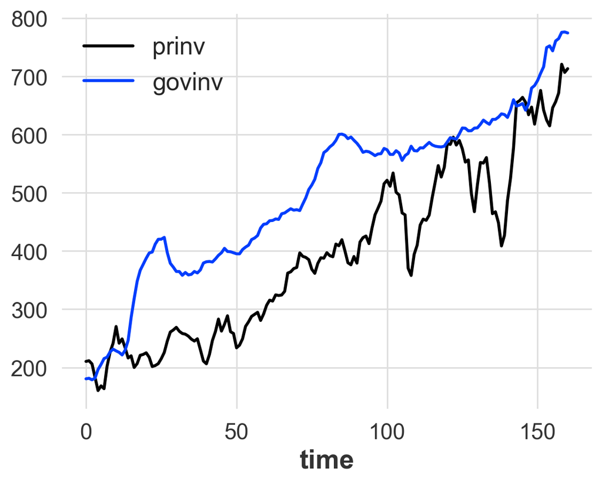

```python
green_invest.plot()
```

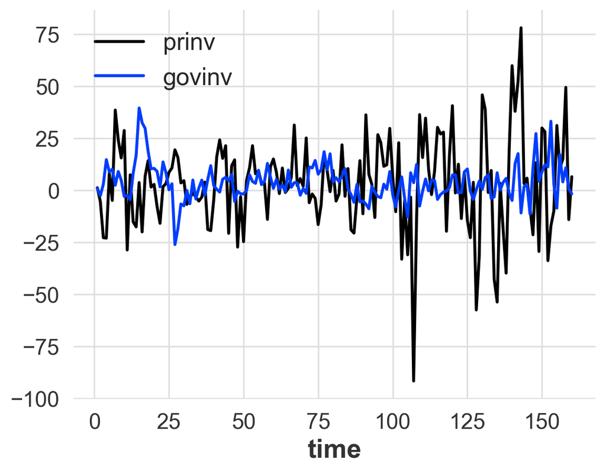

```python
green_invest.diff().plot()
```

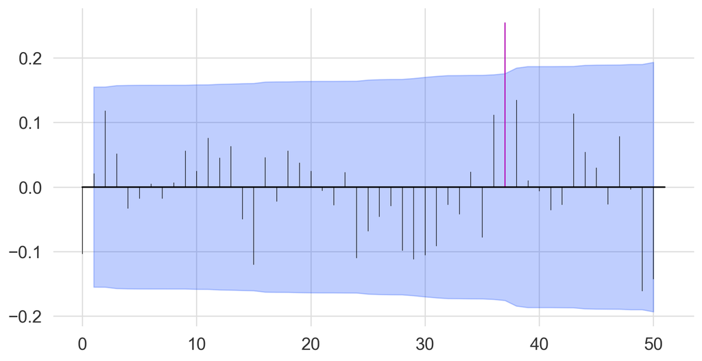

```python
plot_ccf(green_invest["prinv"].diff(), green_invest["govinv"].diff(), max_lag=50, m=37)
```

```python
from darts.models import VARIMA, ARIMA
```

```python
green_invest_train, green_invest_val = green_invest.split_before(150)
```

```python
var = VARIMA(p=37, d=1, q=0)
var.fit(green_invest_train)
fcast = var.predict(len(green_invest_val))
```

```python
ar = ARIMA(p=37, d=1, q=0)
ar.fit(green_invest_train["govinv"])
fcast_ar = ar.predict(len(green_invest_val))
```

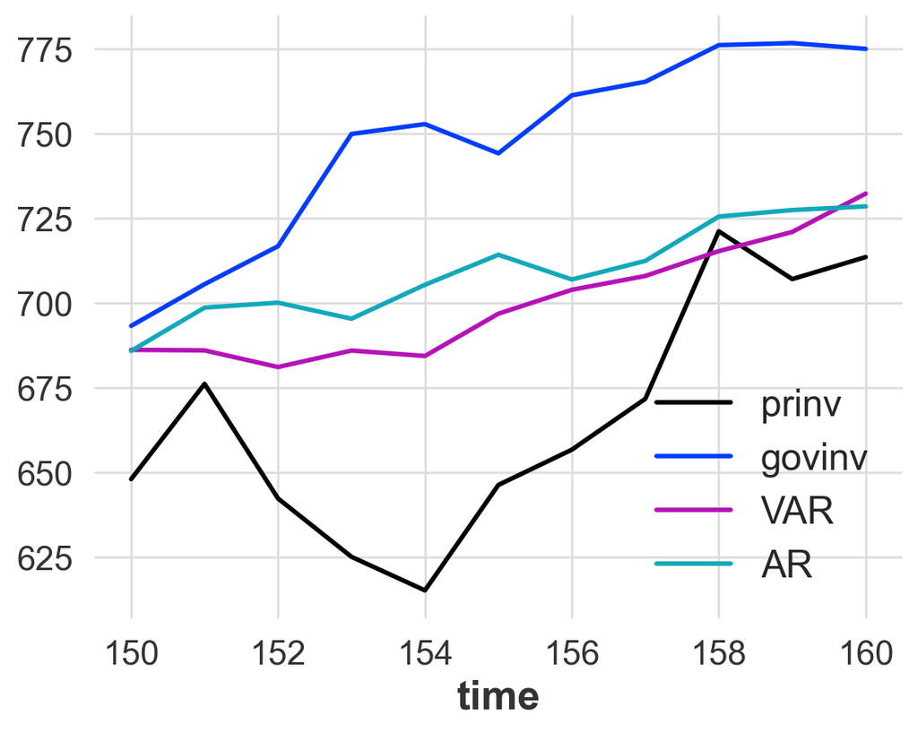

```python
green_invest_val.plot();
fcast["govinv"].plot(label="VAR");
fcast_ar["govinv"].plot(label="AR");
```

## SARIMAX

Series $y_t$, external variables $x_t$: $$ \begin{aligned} y_t & = \sum_{j=1}^k \gamma_j x_{jt} + z_t, \\ z_t & = \alpha_0 + \alpha_1 z_{t-1} + \ldots + \alpha_p z_{t-p} + \varepsilon_t + \beta_1 \varepsilon_{t-1} + \ldots + \beta_q \varepsilon_{t-q} + \\ & + \alpha_S z_{t-S} + \alpha_{2S} z_{t-2S} + \ldots + \alpha_{PS} z_{t-PS} + \\ & + \beta_S \varepsilon_{t-S} + \beta_{2S} \varepsilon_{t-2S} + \ldots + \beta_{PS} \varepsilon_{t-QS} \end{aligned} $$

## SARIMAX vs VAR

There is an important difference between SARIMAX and VAR:

- VAR will forecast each variable
- SARIMAX will only forecast the dependent variable, and requires other variables to be known and supplied

## Non-linear models

There are many cases in which linear relation can't be assumed. Sometimes it can be recovered via a transform of the forecast variable $y$ and/or the predictor variable $x$, e.g. logarithm.

There are also when a more general specification may be required. Then the model we use is $$ y = f(x) + \varepsilon $$ where $f$ is a nonlinear function. One of the simplest specifications is to make $f$ piecewise linear, i.e. making $f(x)$ depend on additional variables $x_k$ such that $$ x_k = \begin{cases} 0, & x < c_k, \\ x - c_k, & x \geqslant c_k \end{cases} $$

Points $c_k$ are called knots or changepoints.

```python
from darts.models import NaiveDrift, ExponentialSmoothing
from darts.utils.utils import ModelMode
```

```python
changepoint = pd.Timestamp("19660101")

ts1, ts2 = gtemp.split_before(changepoint)
```

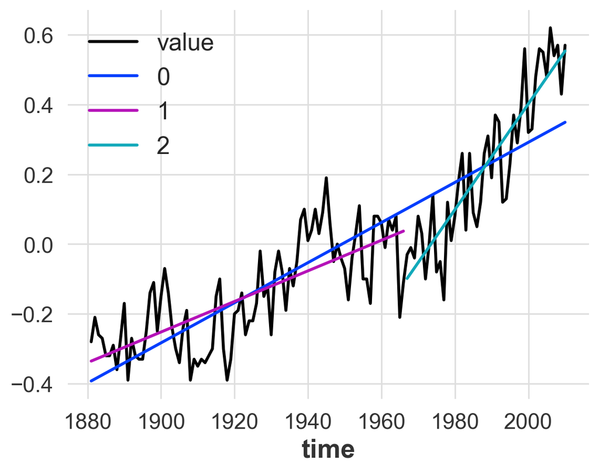

```python
ets0 = ExponentialSmoothing(trend=ModelMode.ADDITIVE, seasonal=ModelMode.NONE, smoothing_level=1e-8).fit(gtemp)
fcast0 = TimeSeries.from_series(pd.Series(ets0.model.fittedvalues, index=gtemp.pd_series().index))
ets1 = ExponentialSmoothing(trend=ModelMode.ADDITIVE, seasonal=ModelMode.NONE, smoothing_level=1e-8).fit(ts1)
fcast1 = TimeSeries.from_series(pd.Series(ets1.model.fittedvalues, index=ts1.pd_series().index))
ets2 = ExponentialSmoothing(trend=ModelMode.ADDITIVE, seasonal=ModelMode.NONE, smoothing_level=1e-8).fit(ts2)
fcast2 = TimeSeries.from_series(pd.Series(ets2.model.fittedvalues, index=ts2.pd_series().index))
gtemp.plot();
fcast0.plot(label="0");
fcast1.plot(label="1");
fcast2.plot(label="2");
```

```python
from darts.metrics.metrics import mse
```

```python
mse([gtemp, gtemp], [fcast0, fcast1.append(fcast2)])
```

```
[0.01542128758992878, 0.009817328388385546]
```

## Testing for structural change

For one changepoint, there is Chow test. Let $r_{t0}, r_{1t}, r_{2t}$ be the residuals of combined model and two separate models respectively, $k_0, k_{1}, k_{2}$ their parameter counts, then $$ F = \frac{(RSS_0 - RSS_1 - RSS_2) / (k_1 + k_2 - k)}{(RSS_1 + RSS_2) / (n - k_1 - k_2)} \sim F(k_1 + k_2 - k, n - k_1 - k_2) $$ where $RSS_i = \sum r_{it}^2$.

```python
resid0 = gtemp[fcast0.start_time():] - fcast0
k0 = ets0.model.k
rss0 = np.sum(ets0.model.resid ** 2)

resid1 = gtemp[fcast1.start_time():fcast1.end_time()] - fcast1
k1 = ets1.model.k
rss1 = np.sum(ets1.model.resid ** 2)

resid2 = gtemp[fcast2.start_time():fcast2.end_time()] - fcast2
k2 = ets2.model.k
rss2 = np.sum(ets2.model.resid ** 2)

stat = ((rss0 - rss1 - rss2) / (k1 + k2 - k0)) / ((rss1 - rss2) / (len(ets0.model.resid) - k1 - k2))

pvalue = sts.f(k1 + k2 - k0, len(ets0.model.resid) - k1 - k2).sf(stat)

print("rejected" if pvalue < 0.05 else "not rejected")
```

```
rejected
```

## Complex seasonalities

- Models we've considered are suitable for rather short seasonal periods, like 2 or 4. If we want to model yearly seasonality in daily data, this would result in too many parameters.
- Also higher frequency time series often exhibit more multiple seasonal patterns.
- 52.18 of weeks in a year, 365.25 days in a year

## Complex seasonalities

Solution:

- Model catches only the shortest seasonality
- Other seasonalities are modeled using regression onto Fourier series (sin and cos with respective periods): $$ \sin \left( \frac{2 \pi k t}{S} \right), \; \cos \left( \frac{2 \pi k t}{S} \right), k = 1, 2, \ldots, K $$

```python
from darts.utils.timeseries_generation import sine_timeseries
from darts import concatenate
from darts.models import ARIMA
```

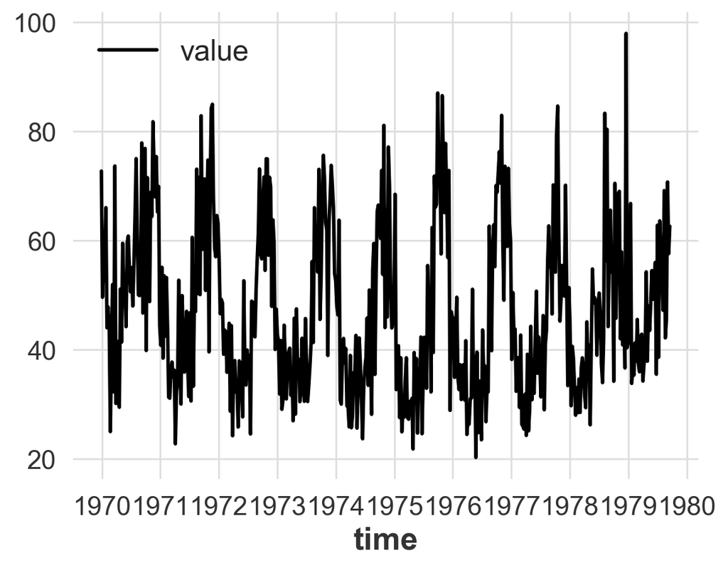

```python
part.plot();
```

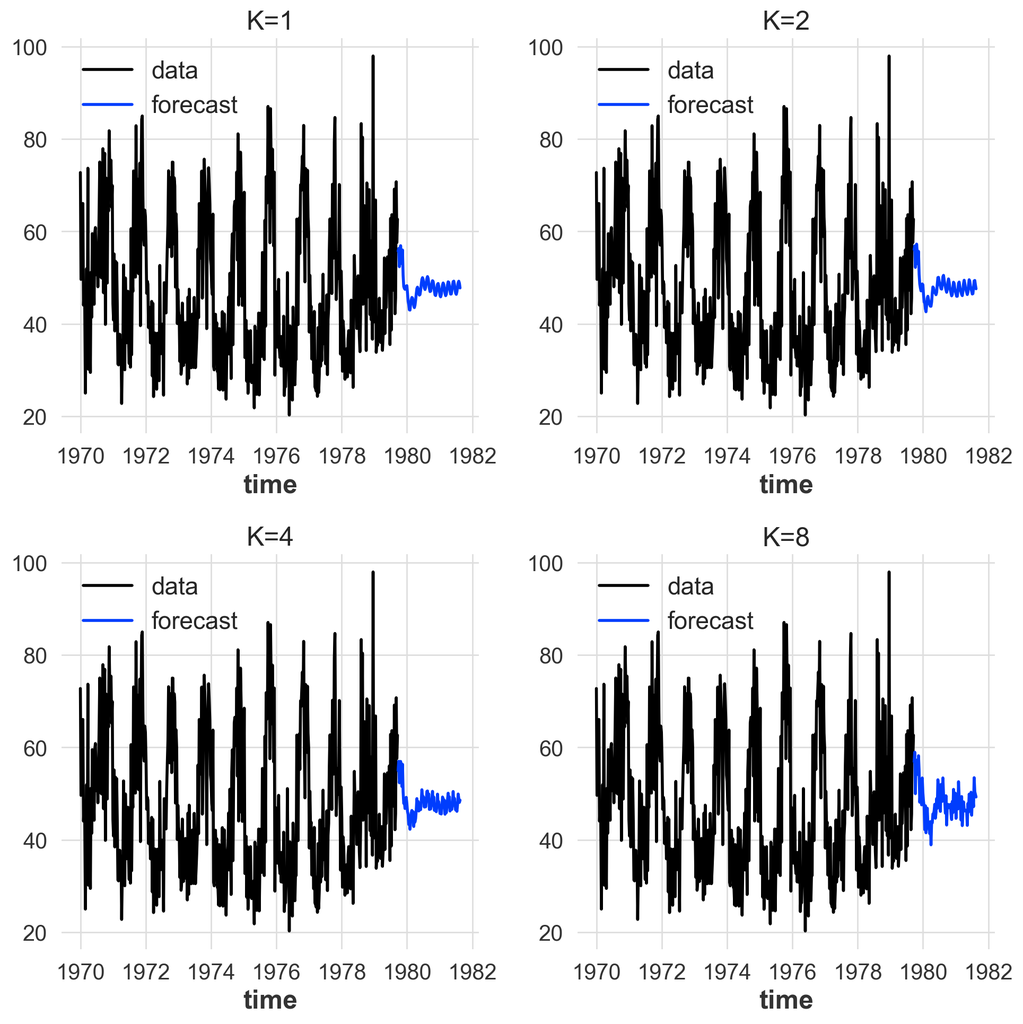

```python
fig, axes = plt.subplots(2, 2, figsize=(10, 10))
for ax, K in zip(axes.flatten(), [1, 2, 4, 8]):
    harmonics = concatenate([
        sine_timeseries(value_frequency=2 * np.pi * k / 52.18, start=part.start_time(), length=len(part) + 100, freq="W-MON")
        for k in range(1, K + 1)
    ] + [
        sine_timeseries(value_frequency=2 * np.pi * k / 52.18, value_phase=np.pi / 2, start=part.start_time(), length=len(part)+100, freq="W-MON")
        for k in range(1, K + 1)
    ], axis="component")

    arima = ARIMA(12, 0, 0)
    arima.fit(part, future_covariates=harmonics)
    fcast = arima.predict(100, future_covariates=harmonics)
    part.plot(label="data", ax=ax)
    fcast.plot(label="forecast", ax=ax)
    ax.set_title(f"{K=}")
plt.tight_layout()
```

```python
harmonics.pd_dataframe()
```

| component time | sine | sine_1 | sine_2 | sine_3 | sine_4 | sine_5 | sine_6 | sine_7 | sine_8 | sine_9 | sine_10 | sine_11 | sine_12 | sine_13 | sine_14 | sine_15 |
| --- | --- | --- | --- | --- | --- | --- | --- | --- | --- | --- | --- | --- | --- | --- | --- | --- |
| 1969-12-29 | 0.000000 | 0.000000 | 0.000000 | 0.000000 | 0.000000 | 0.000000 | 0.000000 | 0.000000 | 1.000000 | 1.000000 | 1.000000 | 1.000000 | 1.000000 | 1.000000 | 1.000000 | 1.000000 |
| 1970-01-05 | 0.686440 | 0.998340 | 0.765520 | 0.115012 | -0.598249 | -0.985090 | -0.834440 | -0.228498 | 0.727187 | 0.057602 | -0.643413 | -0.993364 | -0.801310 | -0.172040 | 0.551099 | 0.973544 |
| 1970-01-12 | 0.998340 | 0.115012 | -0.985090 | -0.228498 | 0.958766 | 0.338950 | -0.919718 | -0.444905 | 0.057602 | -0.993364 | -0.172040 | 0.973544 | 0.284196 | -0.940804 | -0.392580 | 0.895578 |
| 1970-01-19 | 0.765520 | -0.985090 | 0.502119 | 0.338950 | -0.938289 | 0.868464 | -0.179272 | -0.637772 | -0.643413 | -0.172040 | 0.864799 | -0.940804 | 0.345852 | 0.495753 | -0.983800 | 0.770225 |
| 1970-01-26 | 0.115012 | -0.228498 | 0.338950 | -0.444905 | 0.544955 | -0.637772 | 0.722125 | -0.796894 | -0.993364 | 0.973544 | -0.940804 | 0.895578 | -0.838465 | 0.770225 | -0.691763 | 0.604119 |
| ... | ... | ... | ... | ... | ... | ... | ... | ... | ... | ... | ... | ... | ... | ... | ... | ... |
| 1981-07-20 | -0.634724 | 0.980952 | -0.881316 | 0.381102 | 0.292331 | -0.832893 | 0.994887 | -0.704683 | -0.772739 | 0.194251 | 0.472528 | -0.924533 | 0.956317 | -0.553434 | -0.100997 | 0.709523 |
| 1981-07-27 | -0.992001 | 0.250433 | 0.928779 | -0.484905 | -0.806364 | 0.688474 | 0.632557 | -0.848164 | -0.126226 | -0.968134 | 0.370634 | 0.874567 | -0.591420 | -0.725261 | 0.774514 | 0.529734 |
| 1981-08-03 | -0.808017 | -0.952101 | -0.313861 | 0.582273 | 0.999964 | 0.596002 | -0.297684 | -0.946768 | 0.589159 | -0.305783 | -0.949469 | -0.812993 | -0.008496 | 0.802983 | 0.954665 | 0.321916 |
| 1981-08-10 | -0.183157 | -0.360118 | -0.524895 | -0.671913 | -0.796199 | -0.893547 | -0.960663 | -0.995278 | 0.983084 | 0.932907 | 0.851167 | 0.740630 | 0.605035 | 0.448970 | 0.277716 | 0.097065 |
| 1981-08-17 | 0.541638 | 0.910614 | 0.989309 | 0.752636 | 0.276040 | -0.288550 | -0.761158 | -0.991127 | 0.840612 | 0.413257 | -0.145834 | -0.658437 | -0.961146 | -0.957465 | -0.648567 | -0.132921 |

608 rows × 16 columns

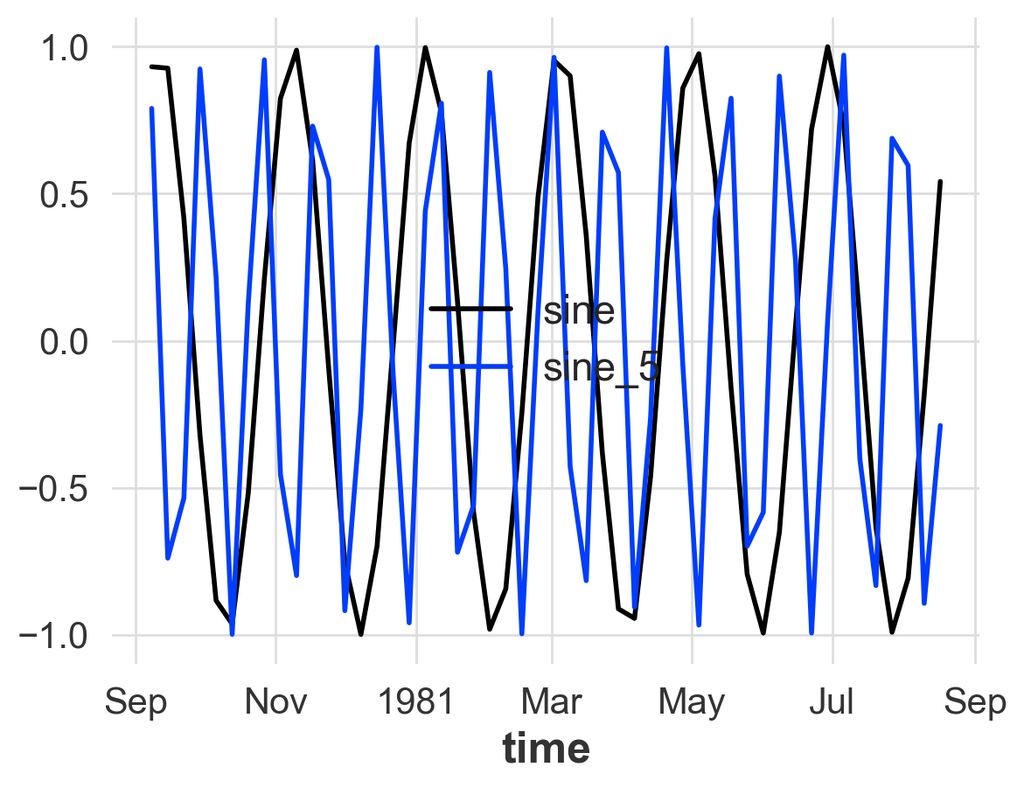

```python
harmonics[["sine", "sine_5"]][-50:].plot()
```

## Facebook Prophet

What if we'd like to make many forecasts, e.g. for every item in every store? It is not possible to do by hand.

Solution: a regression model!

Features:

- lag or other historical features
- seasonality features

Training:

- ordinary regression

Model selection:

- simulate forecasts

## Facebook Prophet

Solution: a regression model $$ x_t = g(t) + s(t) + h(t) + \varepsilon_t $$ where $g(t)$ describes a piecewise-linear trend, $s(t)$ describes the various seasonal patterns, $h(t)$ captures the holiday effects, and $\varepsilon_t$ is a white noise error term.

- The changepoints can be automatically selected
- The seasonal component consists of Fourier terms
- Holiday effects are added as simple dummy variables
- The model is estimated using a Bayesian approach

```python
from darts.models import Prophet
```

```python
prophet = Prophet(suppress_stdout_stderror=True)
prophet.add_seasonality("quarterly", seasonal_periods=4, fourier_order=2)
bcast = prophet.historical_forecasts(gtemp)
```

[output not shown]

[output cut: 199 more lines]

[output not shown]

```python
prophet = Prophet(suppress_stdout_stderror=True)
prophet.add_seasonality("quarterly", seasonal_periods=4, fourier_order=2)
prophet.fit(gtemp)
```

```
17:01:48 - cmdstanpy - INFO - Chain [1] start processing
17:01:48 - cmdstanpy - INFO - Chain [1] done processing
```

```
Prophet(add_seasonalities=None, country_holidays=None, suppress_stdout_stderror=True, add_encoders=None, cap=None, floor=None)
```

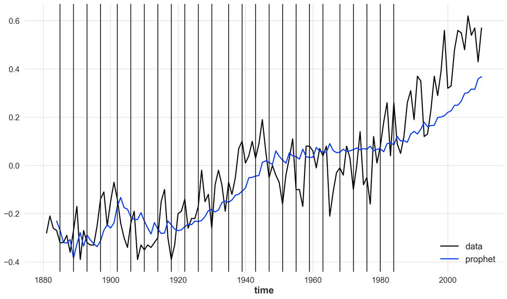

```python
fig, ax = plt.subplots(figsize=(16,9))
gtemp.plot(label="data", ax=ax);
bcast.plot(label="prophet", ax=ax);
[ax.axvline(x, 0, 1) for x in prophet.model.changepoints.values];
```

## ARIMA vs ETS vs Prophet

```python
from darts.models import StatsForecastAutoARIMA as AutoARIMA, StatsForecastAutoETS as AutoETS
from darts.datasets import AirPassengersDataset
```

```python
air_pax = AirPassengersDataset().load().map(lambda ts, x: np.log(x))
```

```python
train, test = air_pax.split_before(pd.Timestamp("19580101"))
```

```python
prophet = Prophet(suppress_stdout_stderror=True)
arima = AutoARIMA(season_length=12)
ets = AutoETS(season_length=12, model="ZZA")
prophet_fcast = prophet.fit(train).predict(len(test), num_samples=50)
arima_fcast = arima.fit(train).predict(len(test), num_samples=50)
ets_fcast = ets.fit(train).predict(len(test), num_samples=50)
```

```
17:05:26 - cmdstanpy - INFO - Chain [1] start processing
17:05:26 - cmdstanpy - INFO - Chain [1] done processing
```

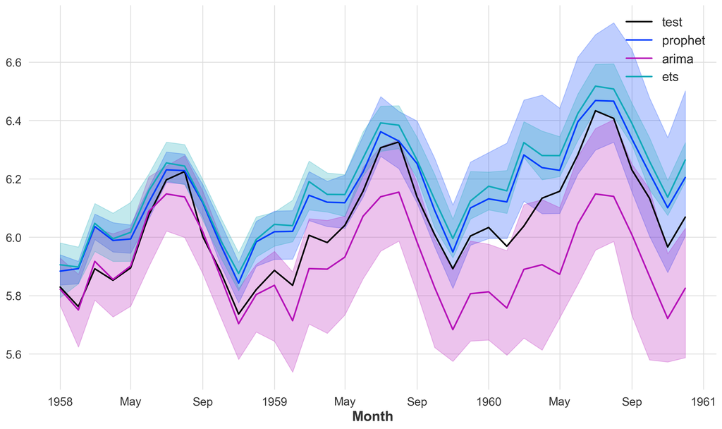

```python
fig, ax = plt.subplots(figsize=(16,9))
# train.plot(label="train", ax=ax);
test.plot(label="test", ax=ax);
prophet_fcast.plot(label="prophet", ax=ax);
arima_fcast.plot(label="arima", ax=ax);
ets_fcast.plot(label="ets", ax=ax);
```

```python
from darts.metrics.metrics import mse
```

```python
mse([test, test, test], [prophet_fcast, arima_fcast, ets_fcast])
```

```
[0.012463915378398775, 0.0267890781907064, 0.019644593072351915]
```

## Combining forecasts

```
16:38:10 - cmdstanpy - INFO - Chain [1] start processing
16:38:10 - cmdstanpy - INFO - Chain [1] done processing
```

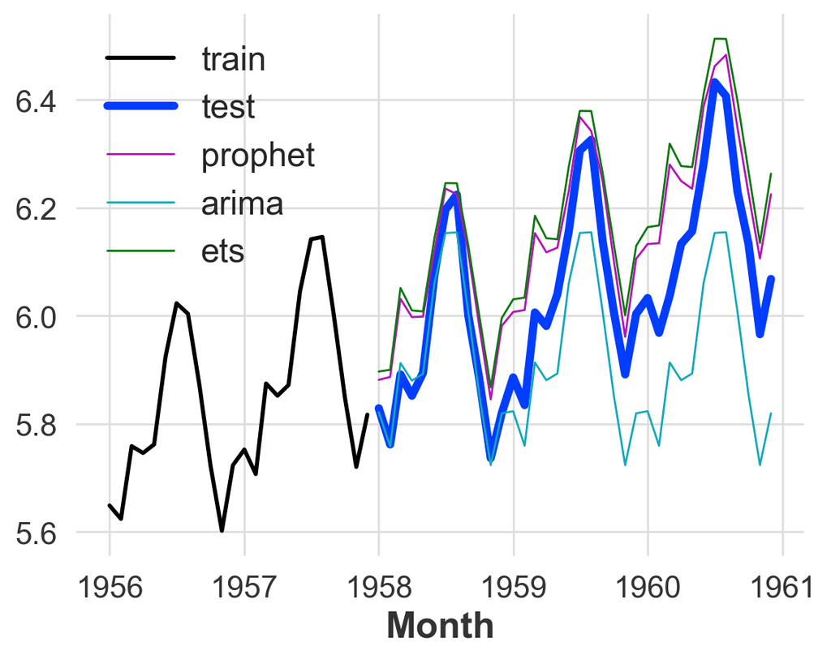

```python
prophet = Prophet(suppress_stdout_stderror=True)
arima = AutoARIMA(season_length=12)
ets = AutoETS(season_length=12, model="ZZA")
prophet_fcast = prophet.fit(train).predict(len(test))
arima_fcast = arima.fit(train).predict(len(test))
ets_fcast = ets.fit(train).predict(len(test))
train[pd.Timestamp("19560101"):].plot(label="train");
test.plot(lw=4, label="test");
prophet_fcast.plot(lw=1, label="prophet");
arima_fcast.plot(lw=1, label="arima");
ets_fcast.plot(lw=1, label="ets");
```

## Combining forecasts

The idea is to use better models when possible via switching mechanism. This can be achieved with a linear combination of different forecasts, where the weights are dynamic and adaptively selected according to certain procedures. There are more ways to combine forecasts, e.g. to regress the series onto kPCA decomposition of forecasts.

Forecast combination puzzle: relative gain of complex methods compared to simple averaging is small and in most cases statistically insignificant.

```
16:36:48 - cmdstanpy - INFO - Chain [1] start processing
16:36:48 - cmdstanpy - INFO - Chain [1] done processing
```

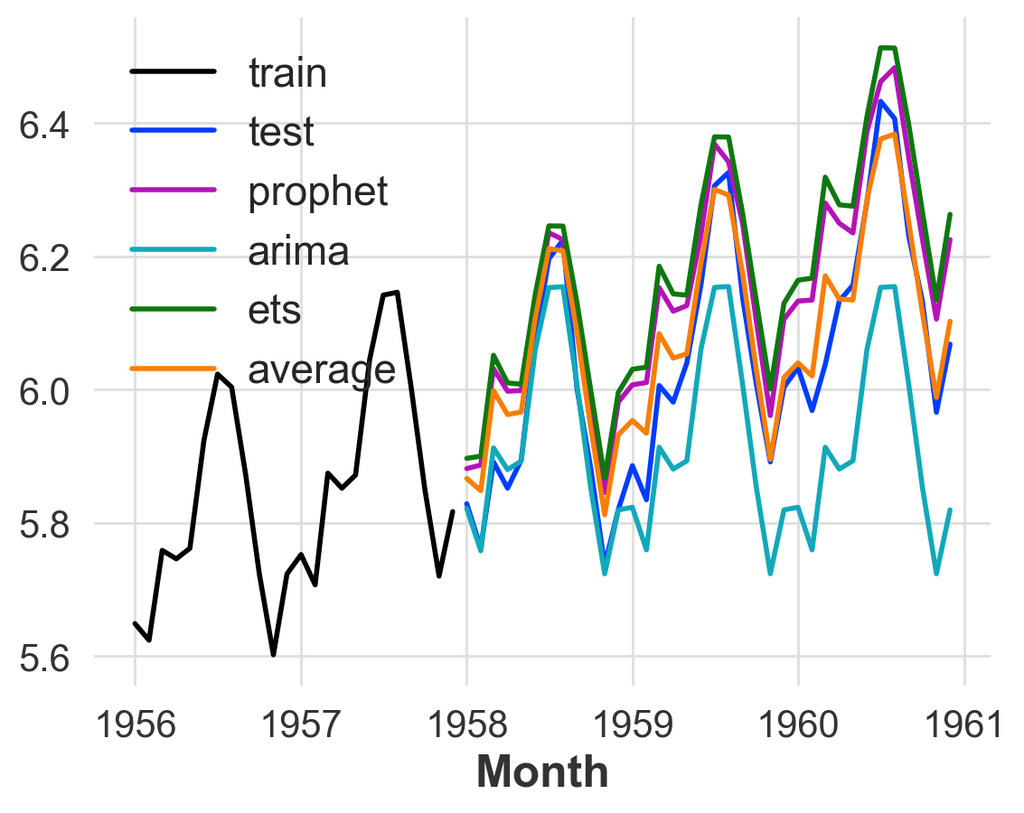

```python
prophet = Prophet(suppress_stdout_stderror=True)
arima = AutoARIMA(season_length=12)
ets = AutoETS(season_length=12, model="ZZA")
prophet_fcast = prophet.fit(train).predict(len(test))
arima_fcast = arima.fit(train).predict(len(test))
ets_fcast = ets.fit(train).predict(len(test))
mean_fcast = concatenate([prophet_fcast, arima_fcast, ets_fcast], axis="component").mean(axis=1)
train[pd.Timestamp("19560101"):].plot(label="train");
test.plot(label="test");
prophet_fcast.plot(label="prophet");
arima_fcast.plot(label="arima");
ets_fcast.plot(label="ets");
mean_fcast.plot(label="average");
```

```python
mse([test, test, test, test], [prophet_fcast, arima_fcast, ets_fcast, mean_fcast])
```

```
[0.013191547807384784,
 0.02497312041630169,
 0.019515006064832693,
 0.00347729907004633]
```

## Forecasting hierarchical time series

We often want to forecast multiple time series that have hierarchical structure, e.g. sales grouped by store, country. The problem is to make the forecasts agree, e.g. so that sales in stores of a country sum to the sales in this country.

```python
from darts.datasets import AustralianTourismDataset
```

```python
tourism = AustralianTourismDataset().load()
```

```python
tourism.pd_dataframe().head()
```

| component time | Total | Hol | VFR | Bus | Oth | NSW - hol | VIC - hol | QLD - hol | SA - hol | WA - hol | ... | TAS - oth - noncity | NT - oth - city | NT - oth - noncity | NSW | VIC | QLD | SA | WA | TAS | NT |
| --- | --- | --- | --- | --- | --- | --- | --- | --- | --- | --- | --- | --- | --- | --- | --- | --- | --- | --- | --- | --- | --- |
| 0 | 84503.0 | 45906.0 | 26042.0 | 9815.0 | 2740.0 | 17589.0 | 10412.0 | 9078.0 | 3089.0 | 3449.0 | ... | 24.0 | 35.0 | 8.0 | 30778.0 | 19020.0 | 17163.0 | 6443.0 | 6841.0 | 3775.0 | 483.0 |
| 1 | 65312.0 | 29347.0 | 20676.0 | 11823.0 | 3466.0 | 11027.0 | 6025.0 | 6310.0 | 1935.0 | 2454.0 | ... | 61.0 | 69.0 | 39.0 | 24395.0 | 12509.0 | 14275.0 | 4492.0 | 6119.0 | 2091.0 | 1431.0 |
| 2 | 72753.0 | 32492.0 | 20582.0 | 13565.0 | 6114.0 | 8910.0 | 5060.0 | 11733.0 | 1569.0 | 3398.0 | ... | 23.0 | 150.0 | 338.0 | 21713.0 | 11261.0 | 22035.0 | 4484.0 | 8191.0 | 1207.0 | 3862.0 |
| 3 | 70880.0 | 31813.0 | 21613.0 | 11478.0 | 5976.0 | 10658.0 | 5481.0 | 8109.0 | 2270.0 | 3561.0 | ... | 43.0 | 172.0 | 453.0 | 24326.0 | 12930.0 | 16179.0 | 4823.0 | 8615.0 | 2103.0 | 1904.0 |
| 4 | 86893.0 | 46793.0 | 26947.0 | 10027.0 | 3126.0 | 16152.0 | 10958.0 | 10047.0 | 3023.0 | 4287.0 | ... | 60.0 | 15.0 | 47.0 | 30869.0 | 19190.0 | 19449.0 | 5554.0 | 7526.0 | 3369.0 | 936.0 |

5 rows × 96 columns

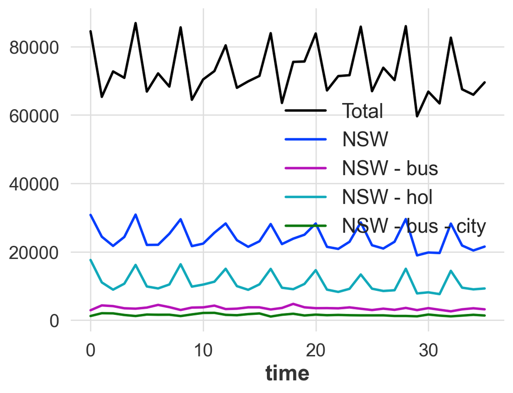

```python
tourism[["Total", "NSW", "NSW - bus", "NSW - hol", "NSW - bus - city"]].plot();
```

```python
reasons = ["Hol", "VFR", "Bus", "Oth"]
regions = ["NSW", "VIC", "QLD", "SA", "WA", "TAS", "NT"]
city_labels = ["city", "noncity"]
```

```python
from itertools import product
```

```python
hierarchy = dict()

# Fill in grouping by reason
for reason in reasons:
    hierarchy[reason] = ["Total"]

# Fill in grouping by region
for region in regions:
    hierarchy[region] = ["Total"]

# Fill in grouping by (region, reason)
for region, reason in product(regions, reasons):
    hierarchy["{} - {}".format(region, reason.lower())] = [reason, region]

# Fill in grouping by (region, reason, <city>)
for region, reason, city in product(regions, reasons, city_labels):
    hierarchy["{} - {} - {}".format(region, reason.lower(), city)] = [
        "{} - {}".format(region, reason.lower())
    ]
```

```python
tourism = tourism.with_hierarchy(hierarchy)
```

```python
train, val = tourism[:-12], tourism[-12:]
```

```python
from darts.models import LinearRegressionModel
```

```python
model = LinearRegressionModel(lags=12)
model.fit(train)
pred = model.predict(n=len(val))
```

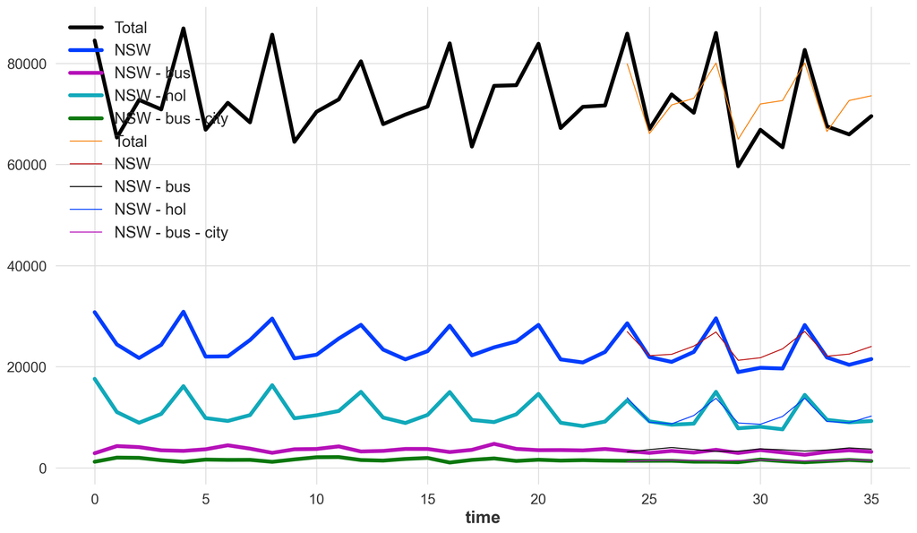

```python
components_to_show = ["Total", "NSW", "NSW - bus", "NSW - hol", "NSW - bus - city"]
plt.figure(figsize=(16, 9))
tourism[components_to_show].plot(lw=4)
pred[components_to_show].plot(lw=1);
```

```python
regions_reasons_comps = list(
    map(lambda t: "{} - {}".format(t[0], t[1].lower()), product(regions, reasons))
)

regions_reasons_city_comps = list(
    map(
        lambda t: "{} - {} - {}".format(t[0], t[1].lower(), t[2]),
        product(regions, reasons, city_labels),
    )
)
```

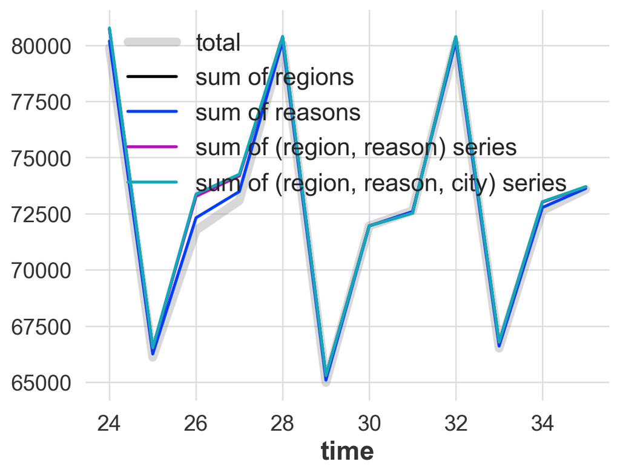

```python
pred["Total"].plot(label="total", lw=6, alpha=0.3, color="grey")
sum([pred[r] for r in regions]).plot(label="sum of regions")
sum([pred[r] for r in reasons]).plot(label="sum of reasons")
sum([pred[t] for t in regions_reasons_comps]).plot(
    label="sum of (region, reason) series"
)
sum([pred[t] for t in regions_reasons_city_comps]).plot(
    label="sum of (region, reason, city) series"
)
```

## Forecasting hierarchical time series: single level approaches

Traditionally, forecasts of hierarchical time series involved selecting one level of aggregation and generating forecasts for that level. These are then either aggregated for higher levels, or disaggregated for lower levels.

```python
from darts.dataprocessing.transformers import BottomUpReconciliator
```

```python
reconciliator = BottomUpReconciliator()
reconcilied_preds = reconciliator.transform(pred)
```

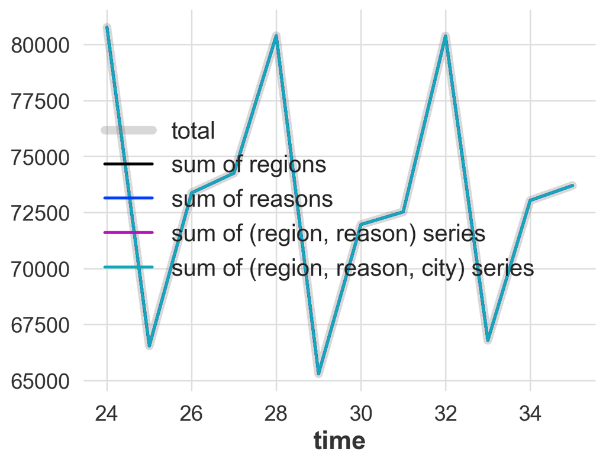

```python
reconcilied_preds["Total"].plot(label="total", lw=6, alpha=0.3, color="grey")
sum([reconcilied_preds[r] for r in regions]).plot(label="sum of regions")
sum([reconcilied_preds[r] for r in reasons]).plot(label="sum of reasons")
sum([reconcilied_preds[t] for t in regions_reasons_comps]).plot(
    label="sum of (region, reason) series"
)
sum([reconcilied_preds[t] for t in regions_reasons_city_comps]).plot(
    label="sum of (region, reason, city) series"
)
```

## Forecasting hierarchical time series: optimal forecast reconciliation

Forecast all levels, then use regression to reconcile.

```python
from darts.dataprocessing.transformers import MinTReconciliator
```

```python
reconciliator = MinTReconciliator(method="wls_val")
reconciliator.fit(train)
reconcilied_preds = reconciliator.transform(pred)
```

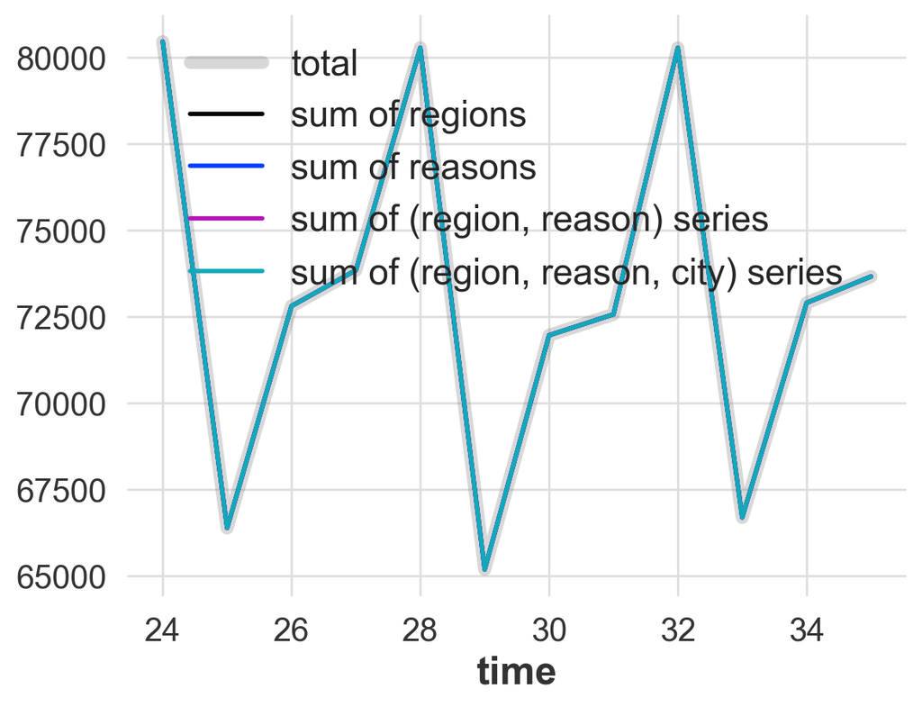

```python
reconcilied_preds["Total"].plot(label="total", lw=6, alpha=0.3, color="grey")
sum([reconcilied_preds[r] for r in regions]).plot(label="sum of regions")
sum([reconcilied_preds[r] for r in reasons]).plot(label="sum of reasons")
sum([reconcilied_preds[t] for t in regions_reasons_comps]).plot(
    label="sum of (region, reason) series"
)
sum([reconcilied_preds[t] for t in regions_reasons_city_comps]).plot(
    label="sum of (region, reason, city) series"
)
```

# Webinar

## Pipeline of working with time series

- Visualize data, analyze the distribution of the feature. In case the variance is not constant, make a transformation (e.g. log). Check for and remove outliers.
- Estimate ARIMA: plot ACF/PACF, find starting parameters $p$, $q$, look for better parameters in their proximity. Check the residuals. Estimate AutoARIMA, check if it is adequate, check the residuals.
- Estimate ETS: use AutoETS to find the optimal combination of trend/seasonality/error. Check if it is adequate, check the residuals.
- Visual analysis of the forecast, if necessary - check for necessity of a combined model.
- Compare the models and pick the best. Make conclusions.

```python
salaries = pd.read_csv("/Users/nstulov/Downloads/monthly-wage.csv")
```

```python
salaries = salaries.iloc[:-1]
salaries["Month"] = salaries["Month"] + "-01"
salaries["Month"] = pd.to_datetime(salaries["Month"])
```

```python
salaries_ts = TimeSeries.from_dataframe(salaries, time_col="Month", value_cols=["Average nominal wage, rub/month"])
```

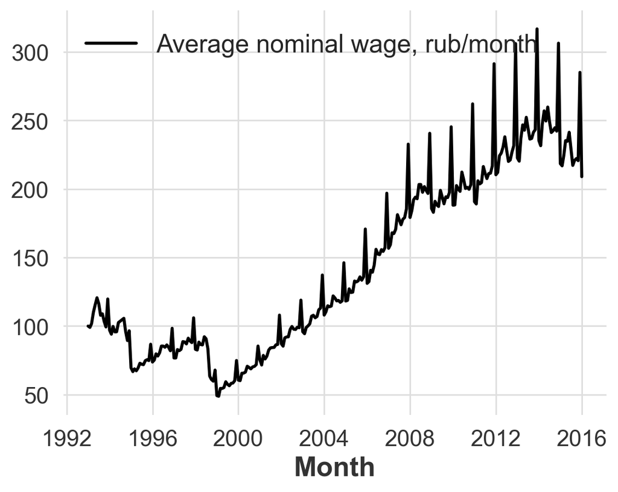

```python
salaries_ts.plot()
```

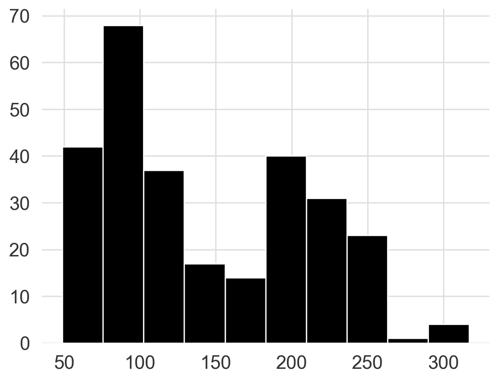

```python
plt.hist(salaries_ts.values())
```

```python
salaries_ts_log = salaries_ts.map(lambda ts: np.log(ts))
```

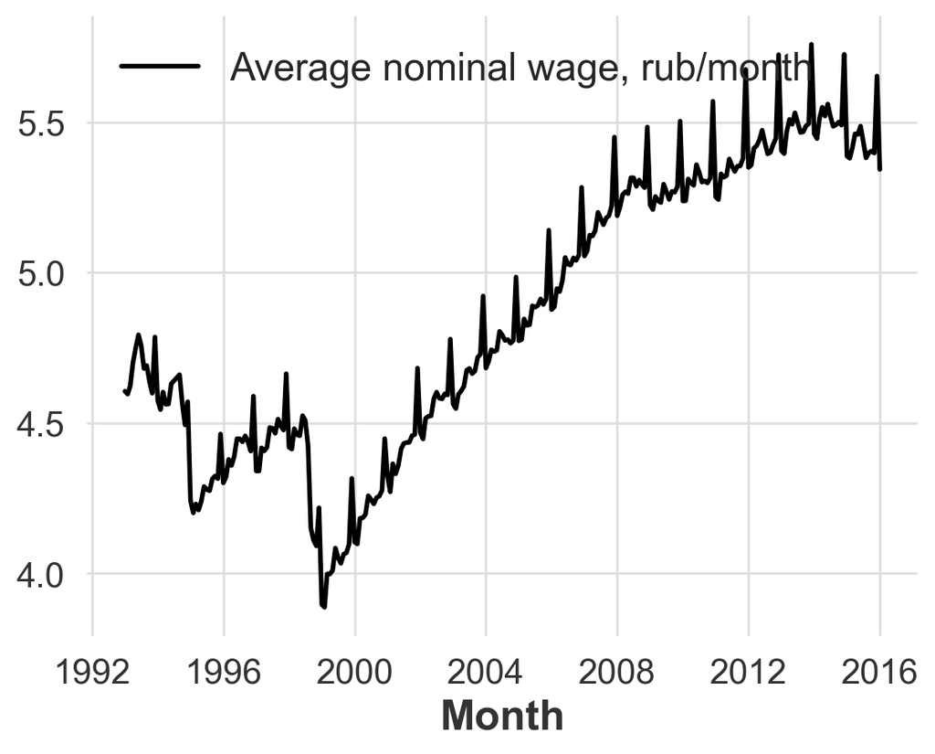

```python
salaries_ts_log.plot()
```

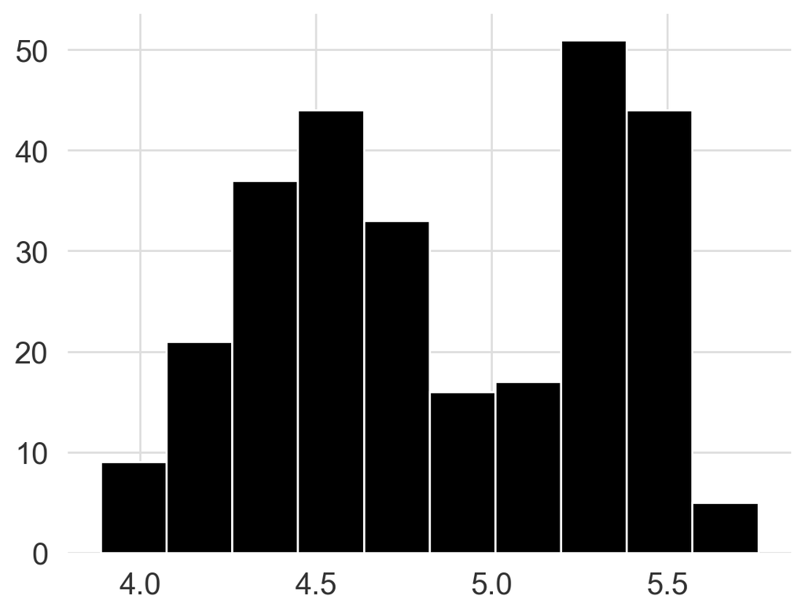

```python
plt.hist(salaries_ts_log.values())
```

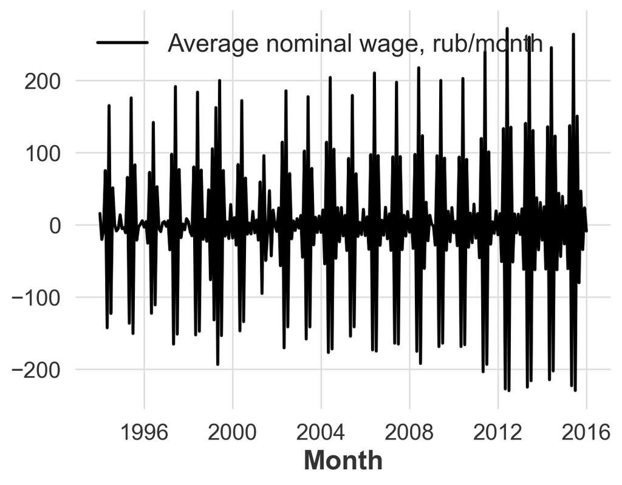

```python
salaries_ts_log.diff(12).plot()
```

```python
_, pvalue, _, _ = tsa.stattools.kpss(salaries_ts_log.diff(12).values())
pvalue
```

```
0.1
```

```python
pvalue < 0.05
```

```
False
```

```python
# D = 1 * S
# d = 0
```

```python
salaries_ts_log_diff = salaries_ts_log.diff(12)
```

```python
from darts.utils.statistics import plot_acf, plot_pacf
```

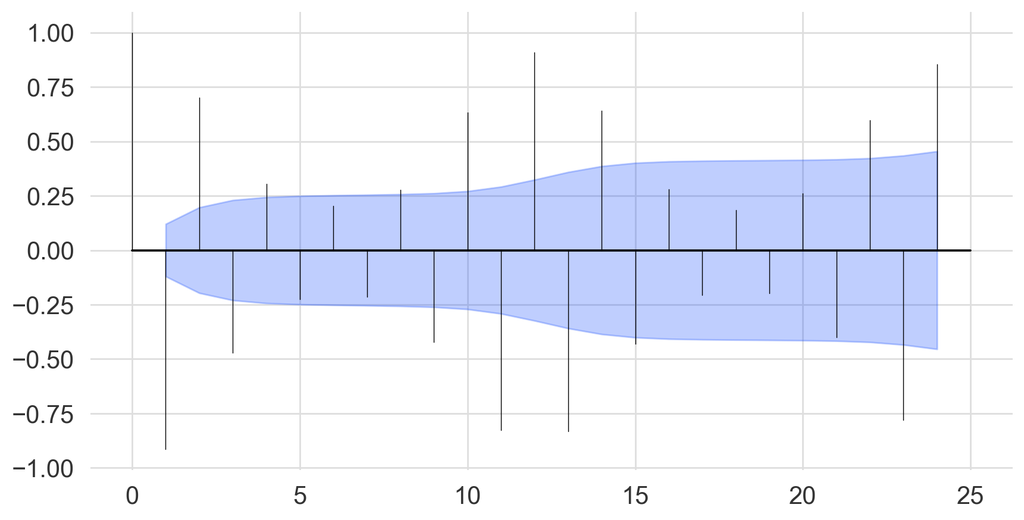

```python
plot_acf(salaries_ts_log_diff)
```

```python
# q = 4
# S = 12
# Q = 1 * S
```

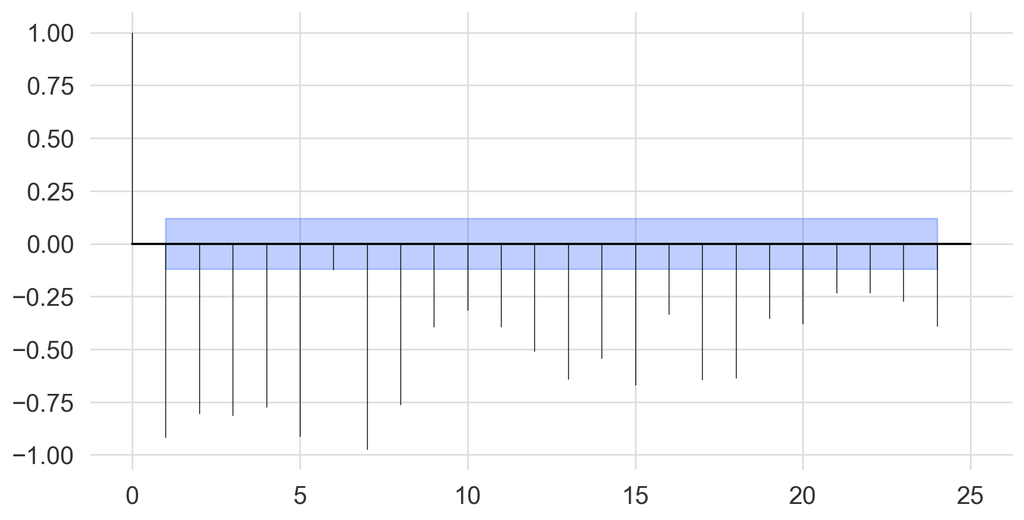

```python
plot_pacf(salaries_ts_log_diff)
```

```python
# p = 5
# P = 0 * S
```

```python
arima = ARIMA(p=5, d=0, q=4, seasonal_order=(0, 1, 1, 12))
```

```python
bcast = arima.historical_forecasts(salaries_ts_log)
```

[output not shown]

[output cut: 419 more lines]

[output not shown]